# graphTweets - Applications

John Coene

March - 2016

# Setup

# Install

graphTweets is available on CRAN and github.

```r
# from CRAN
install.packages("graphTweets")

# from github
devtools::install_github("JohnCoene/graphTweets")

# load
library(graphTweets)
```

# Functions

graphTweets only comes with *two* functions

```r
help(graphTweets)
```

# Data

Set yourself up with [twitteR](https://cran.r-project.org/web/packages/twitteR/index.html) or [streamR](https://cran.r-project.org/web/packages/streamR/index.html) to fetch tweets (you may of course import data in some other way).

Data sets used in these slides:

- [rstats.RData](https://github.com/JohnCoene/docs/raw/master/data/r_tw.RData) - 500 tweets on #rstats.
- presi.RData - 9350 tweets on the US Presidential 2016.

# Example 01

# search Twitter

Here I use the tiwtteR package to get 500 tweets on “#rstats”.

```r
library(twitteR)

# replace with your details
setup_twitter_oauth(consumer_key, consumer_secret, access_token,
                    access_secret)
r_tw <- searchTwitter("rstats", n = 500)

# unlist tweets to data.frame
r_tw <- twListToDF(r_tw)
```

[download](https://github.com/JohnCoene/docs/raw/master/data/r_tw.RData) this dataset.

# get Edges

We can now get the list of edges using graphTweets.

```r
# get edges
edges <- graphTweets::getEdges(r_tw, "text", "screenName")

# remove dupliactes
edges <- edges[!duplicated(edges),]
```

# igraph build

We may then use [igraph](http://igraph.org/r/) to build and plot the network.

```r
# build
g <- igraph::graph.data.frame(edges, directed = TRUE)

# plot
igraph::plot.igraph(g, layout = layout.fruchterman.reingold(g))
```

# igraph plot

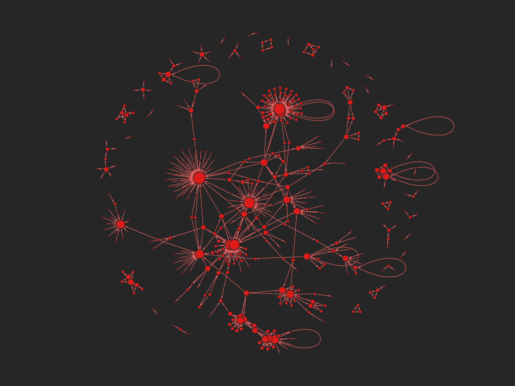

# networkD3

You may also use the networkD3 package.

```r
networkD3::simpleNetwork(edges, Source = "source", Target = "target")
```

[interactive chart not shown]

# Export

Alternatively one may use the igraph package to save the graph and import it in another software.

For instance you may want to save the graph as `graphml`.

```r
write.graph(g, file = "graphTweets.graphml", format = "graphml")
```

Then open it in [Gephi](https://gephi.org/).

# Example 02

# build graph

Let’s use the same data set as in the previous example but this time add meta-data to the nodes.

```r
# graphTweets
edges <- getEdges(r_tw, source = "screenName", tweets = "text",
                  str.length = NULL, "favoriteCount")

nodes <- getNodes(edges, source = "source", target = "target", "favoriteCount")

# replace NA with 0
nodes$retweetCount[is.na(nodes$retweetCount)] <- 0

# build graph
g <- igraph::graph.data.frame(edges, directed = TRUE, vertices = nodes)
```

# make plot

Now we can use the meta-data (`favoriteCount`) in the plot.

```r
# scale vertices color to # of favorites
pal <- RColorBrewer:::brewer.pal(5, "Dark2")
V(g)$color <- colorRampPalette(pal)(length(V(g)$favoriteCount))

# plot vertex size ~ degree
plot(g, layout = layout.fruchterman.reingold(g), vertex.color = V(g)$color,
     vertex.size = log1p(degree(g)) * 3)
```

# plot

[figure not shown]

# Example 03

# Get tweets

```r
# search terms 2016 presidential
st <- c("hillary", "clinton", "bernie", "sanders", "donald", "trump", "jeb",
        "bush", "ted", "cruz", "marco", "rubio", "carson", "christie")

presi <- data.frame()

for(i in 10:length(st)) {
  # tweets from the US
  tw <- searchTwitter(st[i], n = 5000, geocode = "39.554883,-99.931641,1000mi")

  tw <- twListToDF(tw)

  presi <- plyr::rbind.fill(presi, tw)
}
```

[download](https://github.com/JohnCoene/docs/raw/master/data/presi.RData) this dataset.

# get Edges

We pass additional variables (`...`) to the `getEdges` function; tweets’ retweet count and their geo-coordinates so that we can later layout the network on a map rather than a canvas.

```r
# remove NA
presi <- presi[!is.na(presi$longitude),]

edges <- getEdges(data = presi, tweets = "text", source = "screenName",
                  str.length = NULL, "longitude", "latitude", "retweetCount")
```

# get Nodes

We then pass the geo-coordinates and retweet counts as meta-data to our vertices using `getNodes`.

```r
nodes <- getNodes(edges, source = names(edges)[1], target = names(edges)[2],
                  "longitude", "latitude", "retweetCount")
```

# build graph

Here I demonstrate with [plotly](https://plot.ly/r) as igraph cannot—on my machine—properly handle 3447 nodes.

```r
# join nodes and edges and rename
edges <- dplyr::inner_join(edges[,1:2], nodes[,1:3],
                           by = c("source" = "nodes"))
edges <- dplyr::inner_join(edges, nodes[,1:3], by = c("target" = "nodes"))
names(edges)[3:ncol(edges)] <- c("lon_start", "lat_start", "lon_end",
                                 "lat_end")

# remove NA
edges <- edges[!is.na(edges$lon_end),]

# edges frequency to use for opacity in plot
edges$freq <- 1
edges <- plyr::ddply(edges, c("source", "target", "lon_start", "lat_start",
                              "lon_end", "lat_end"),
                     plyr::summarise, freq = sum(freq))

# add id for plotly
edges$id <- 1:nrow(edges)

# plot
plot_ly(nodes, lon = longitude, lat = latitude, type = 'scattergeo',
        locationmode = 'USA-states',
        marker = list(size = log1p(retweetCount * 3)*5, color = 'red'),
        inherit = FALSE) %>%
  add_trace(lon = list(lon_start, lon_end), lat = list(lat_start, lat_end)
            group = id, opacity = 1, data = edges,
            mode = 'lines', line = list(width = freq, color = '#DD1C1A'),
            type = 'scattergeo', locationmode = 'USA-states') %>%
  layout(title = 'graphTweets',
         geo = list(scope = 'north america',
                    projection = list(type = 'azimuthal equal area')),
         showlegend = FALSE)
```

# plot

[interactive chart not shown]

# Example 04

# Communities

Detect communities in our graph. Somewhat useful though it is not a giant component like ego networks.

- modularity: 0.848
- number of communities: 53

```r
edges <- getEdges(data = r_tw, tweets = "text", source = "screenName",
                  str.length = NULL)

nodes <- getNodes(edges, source = "source", target = "target")

g <- igraph::graph.data.frame(edges, directed = TRUE, vertices = nodes)

# get communities
cm <- walktrap.community(g)
```

# plot

Plotting communities with igraph cound’t be easier.

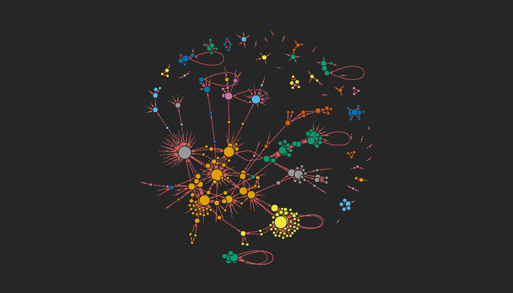

```r
plot(g, vertex.color = membership(cm), vertex.size = log1p(degree(g)) * 3)
```

# Outro

# Resources

If you encounter issues go to, [Github issues](https://github.com/JohnCoene/graphTweets/issues).

For the manual go on [CRAN](https://cran.r-project.org/web/packages/graphTweets/).

See my other packages and projects at http://johncoene.github.io/projects/